# Section 3.4 Python Code and Analysis

## The `Student Performance` Example

In this final section we illustrate the practical implementation of the variable-selection and shrinkage methods developed earlier, using a real data example.

The analysis is based on the `student-mat.csv` data set, which contains information on student achievement in secondary education at two Portuguese schools. The original study is described in:

> Cortez, P., & Silva, A. M. G. (2008). Using data mining to predict secondary school student performance. *Proceedings of the 5th Annual Future Business Technology Conference*.

The data are publicly available from the UCI Machine Learning Repository:  
[Student Performance data set](https://archive.ics.uci.edu/dataset/320/student+performance).

The variables in the data set are the following:

- `school` – student’s school (*binary*: `GP` – Gabriel Pereira or `MS` – Mousinho da Silveira)
- `sex` – student’s sex (*binary*: `F` – female or `M` – male)
- `age` – student’s age (*numeric*: from 15 to 22)
- `address` – home address type (*binary*: `U` – urban or `R` – rural)
- `famsize` – family size (*binary*: `LE3` – ≤ 3 or `GT3` – > 3)
- `Pstatus` – parent’s cohabitation status (*binary*: `T` – living together or `A` – apart)
- `Medu` – mother’s education (*numeric*: 0 – none, 1 – primary (4th grade), 2 – 5th–9th grade, 3 – secondary, 4 – higher education)
- `Fedu` – father’s education (*numeric*: same coding as `Medu`)
- `Mjob` – mother’s occupation (*nominal*: `teacher`, `health`, `services`, `at_home`, `other`)
- `Fjob` – father’s occupation (*nominal*: same categories as `Mjob`)
- `reason` – reason for choosing the school (*nominal*: `home`, `reputation`, `course`, `other`)
- `guardian` – student’s guardian (*nominal*: `mother`, `father`, `other`)
- `traveltime` – home-to-school travel time (*numeric*: 1 – <15 min, 2 – 15–30 min, 3 – 30–60 min, 4 – >1 hour)
- `studytime` – weekly study time (*numeric*: 1 – <2 h, 2 – 2–5 h, 3 – 5–10 h, 4 – >10 h)
- `failures` – number of past class failures (*numeric*: *n* if 1 ≤ *n* < 3, else 4)
- `schoolsup` – extra educational support (*binary*: `yes`/`no`)
- `famsup` – family educational support (*binary*: `yes`/`no`)
- `paid` – extra paid classes in the course subject (*binary*: `yes`/`no`)
- `activities` – extra-curricular activities (*binary*: `yes`/`no`)
- `nursery` – attended nursery school (*binary*: `yes`/`no`)
- `higher` – wants to take higher education (*binary*: `yes`/`no`)
- `internet` – Internet access at home (*binary*: `yes`/`no`)
- `romantic` – in a romantic relationship (*binary*: `yes`/`no`)
- `famrel` – quality of family relationships (*numeric*: 1 – very bad to 5 – excellent)
- `freetime` – free time after school (*numeric*: 1 – very low to 5 – very high)
- `goout` – going out with friends (*numeric*: 1 – very low to 5 – very high)
- `Dalc` – workday alcohol consumption (*numeric*: 1 – very low to 5 – very high)
- `Walc` – weekend alcohol consumption (*numeric*: 1 – very low to 5 – very high)
- `health` – current health status (*numeric*: 1 – very bad to 5 – very good)
- `absences` – number of school absences (*numeric*: 0 to 93)
- `G1` – first-period grade (*numeric*: 0 to 20)
- `G2` – second-period grade (*numeric*: 0 to 20)
- `G3` – final grade (*numeric*: 0 to 20; the response variable)

```python
import pandas as pd

stu_performance0 = pd.read_csv("student-mat.csv", sep=';')
```

Our goal is to predict the final grade (G3) using the penalized regression methods studied in this chapter. Because standard ridge and lasso do not handle categorical predictors directly (a group-lasso formulation would be required), we restrict attention to the numeric predictors only.

```python
cols_to_drop = [
    'school', 'sex', 'address', 'famsize', 'Pstatus',
    'Mjob', 'Fjob', 'reason', 'guardian', 'schoolsup',
    'famsup', 'paid', 'activities', 'nursery', 'higher',
    'internet', 'romantic', 'G1', 'G2'
]
stu_performance = stu_performance0.drop(columns=cols_to_drop) # data frame without categorical variables

# manually renaming response to 'Grades'
stu_performance = stu_performance.rename(columns={'G3': 'Grades'})

n = stu_performance.shape[0]  # sample size (number of rows)
p = stu_performance.shape[1] - 1  # number of non-intercept predictors (columns - 1)

stu_performance.head()
```

|  | age | Medu | Fedu | traveltime | studytime | failures | famrel | freetime | goout | Dalc | Walc | health | absences | Grades |
| --- | --- | --- | --- | --- | --- | --- | --- | --- | --- | --- | --- | --- | --- | --- |
| 0 | 18 | 4 | 4 | 2 | 2 | 0 | 4 | 3 | 4 | 1 | 1 | 3 | 6 | 6 |
| 1 | 17 | 1 | 1 | 1 | 2 | 0 | 5 | 3 | 3 | 1 | 1 | 3 | 4 | 6 |
| 2 | 15 | 1 | 1 | 1 | 2 | 3 | 4 | 3 | 2 | 2 | 3 | 3 | 10 | 10 |
| 3 | 15 | 4 | 2 | 1 | 3 | 0 | 3 | 2 | 2 | 1 | 1 | 5 | 2 | 15 |
| 4 | 16 | 3 | 3 | 1 | 2 | 0 | 4 | 3 | 2 | 1 | 2 | 5 | 4 | 10 |

We begin by fitting the **full linear model** that includes every numeric predictor:

```python
import statsmodels.formula.api as smf

# due to error with patsy ~. formula, workaround by building the formula "explicitly"
predictors = stu_performance.columns.drop("Grades")
formula = "Grades ~ " + " + ".join(predictors)

performance_full = smf.ols(formula=formula, data=stu_performance).fit()
performance_full.summary()
```

OLS Regression Results

| Dep. Variable: | Grades | R-squared: | 0.183 |
| --- | --- | --- | --- |
| Model: | OLS | Adj. R-squared: | 0.155 |
| Method: | Least Squares | F-statistic: | 6.564 |
| Date: | Fri, 21 Aug 2026 | Prob (F-statistic): | 2.53e-11 |
| Time: | 12:15:49 | Log-Likelihood: | -1121.3 |
| No. Observations: | 395 | AIC: | 2271. |
| Df Residuals: | 381 | BIC: | 2326. |
| Df Model: | 13 |  |  |
| Covariance Type: | nonrobust |  |  |

|  | coef | std err | t | P>\|t\| | [0.025 | 0.975] |
| --- | --- | --- | --- | --- | --- | --- |
| Intercept | 13.5370 | 3.337 | 4.056 | 0.000 | 6.975 | 20.099 |
| age | -0.2562 | 0.179 | -1.433 | 0.153 | -0.608 | 0.095 |
| Medu | 0.5849 | 0.257 | 2.280 | 0.023 | 0.081 | 1.089 |
| Fedu | -0.0913 | 0.255 | -0.359 | 0.720 | -0.592 | 0.409 |
| traveltime | -0.4018 | 0.314 | -1.278 | 0.202 | -1.020 | 0.216 |
| studytime | 0.2658 | 0.269 | 0.988 | 0.324 | -0.263 | 0.795 |
| failures | -1.8315 | 0.312 | -5.870 | 0.000 | -2.445 | -1.218 |
| famrel | 0.2802 | 0.245 | 1.142 | 0.254 | -0.202 | 0.763 |
| freetime | 0.3414 | 0.231 | 1.478 | 0.140 | -0.113 | 0.796 |
| goout | -0.6264 | 0.222 | -2.824 | 0.005 | -1.062 | -0.190 |
| Dalc | -0.1372 | 0.320 | -0.428 | 0.669 | -0.767 | 0.493 |
| Walc | 0.3531 | 0.238 | 1.482 | 0.139 | -0.116 | 0.822 |
| health | -0.1743 | 0.156 | -1.116 | 0.265 | -0.481 | 0.133 |
| absences | 0.0320 | 0.028 | 1.158 | 0.247 | -0.022 | 0.086 |

| Omnibus: | 28.620 | Durbin-Watson: | 2.062 |
| --- | --- | --- | --- |
| Prob(Omnibus): | 0.000 | Jarque-Bera (JB): | 32.727 |
| Skew: | -0.677 | Prob(JB): | 7.82e-08 |
| Kurtosis: | 3.391 | Cond. No. | 314. |

Notes:  
[1] Standard Errors assume that the covariance matrix of the errors is correctly specified.

A simple (but inefficient) approach to model selection is to compare the full model with a reduced model that retains only the apparently significant variables, *using a partial F-test*:

```python
import statsmodels.api as sm
from statsmodels.stats.anova import anova_lm

# first we fit a reduced model
formula_reduced = 'Grades ~ failures + goout + Medu'
performance_red = smf.ols(formula=formula_reduced, data=stu_performance).fit()

anova_results = anova_lm(performance_red, performance_full)
print(anova_results)
```

```
   df_resid          ssr  df_diff     ss_diff         F    Pr(>F)
0     391.0  6956.920171      0.0         NaN       NaN       NaN
1     381.0  6756.704779     10.0  200.215392  1.128983  0.338977
```

In this case, we fail to reject the null so the reduced model is preferred. However, this approach is not efficient nor optimal. Therefore, we use algorithms to search the space of models and a penalty to penalize the inclusion of terms that are not as useful.

### Subset Selection via Level-wise algorithms

```python
import itertools
import statsmodels.api as sm
import pandas as pd
import numpy as np

# Data
X = stu_performance.drop(columns="Grades")
y = stu_performance["Grades"]

# Full model MSE for Mallows' Cp
sigma2_full = performance_full.mse_resid

# max subset size
nvmax = X.shape[1]

# we will store the best model per subset size
best_per_size = []

for k in range(1, nvmax + 1):
    best_model = None
    best_rsq = -np.inf

    # Loop over all combinations of size k using itertools combinations
    for combo in itertools.combinations(X.columns, k):
        X_subset = sm.add_constant(X[list(combo)])
        model = sm.OLS(y, X_subset).fit()

        if model.rsquared > best_rsq:
            best_rsq = model.rsquared
            best_model = {
                "k": k,
                "predictors": combo,
                "rsq": model.rsquared,
                "adj_rsq": model.rsquared_adj,
                "bic": model.bic,
                "aic": model.aic,
                "rss": model.ssr
            }

    # Compute Mallows' Cp
    best_model["cp"] = best_model["rss"] / sigma2_full - (len(y) - 2*len(best_model["predictors"]))
    best_per_size.append(best_model)


rs = pd.DataFrame(best_per_size)
```

The `rs` object above contains all the different criteria for all the models that have been evaluated.

Below we extract the $R^2$, Adjusted $R^2$, $AIC$, $BIC$ and $C_p$-Mallows criteria for the 13 models that have been evaluated:

```python
rs
```

|  | k | predictors | rsq | adj_rsq | bic | aic | rss | cp |
| --- | --- | --- | --- | --- | --- | --- | --- | --- |
| 0 | 1 | (failures,) | 0.129899 | 0.127685 | 2279.346318 | 2271.388546 | 7195.656554 | 12.751803 |
| 1 | 2 | (Medu, failures) | 0.148313 | 0.143968 | 2276.875838 | 2264.939180 | 7043.370273 | 6.164618 |
| 2 | 3 | (Medu, failures, goout) | 0.158767 | 0.152313 | 2277.976507 | 2262.060964 | 6956.920171 | 3.289832 |
| 3 | 4 | (Medu, failures, freetime, goout) | 0.163370 | 0.154789 | 2281.788229 | 2261.893800 | 6918.855608 | 3.143431 |
| 4 | 5 | (Medu, traveltime, failures, freetime, goout) | 0.166832 | 0.156123 | 2286.128964 | 2262.255649 | 6890.221033 | 3.528772 |
| 5 | 6 | (Medu, traveltime, failures, freetime, goout, ... | 0.169663 | 0.156823 | 2290.763350 | 2262.911150 | 6866.807998 | 4.208548 |
| 6 | 7 | (age, Medu, traveltime, failures, freetime, go... | 0.172408 | 0.157439 | 2295.434493 | 2263.603407 | 6844.111358 | 4.928720 |
| 7 | 8 | (age, Medu, traveltime, failures, freetime, go... | 0.174691 | 0.157586 | 2300.322023 | 2264.512051 | 6825.227682 | 5.863899 |
| 8 | 9 | (age, Medu, traveltime, failures, famrel, free... | 0.177358 | 0.158127 | 2305.022777 | 2265.233919 | 6803.178460 | 6.620578 |
| 9 | 10 | (age, Medu, traveltime, failures, famrel, free... | 0.180038 | 0.158685 | 2309.712285 | 2265.944542 | 6781.007415 | 7.370388 |
| 10 | 11 | (age, Medu, traveltime, studytime, failures, f... | 0.182315 | 0.158831 | 2314.592990 | 2266.846361 | 6762.181008 | 8.308796 |
| 11 | 12 | (age, Medu, traveltime, studytime, failures, f... | 0.182701 | 0.157027 | 2320.385250 | 2268.659736 | 6758.986840 | 10.128682 |
| 12 | 13 | (age, Medu, Fedu, traveltime, studytime, failu... | 0.182977 | 0.155100 | 2326.230748 | 2270.526348 | 6756.704779 | 12.000000 |

Going by $r^2$, the best model is the 13th as expected. By adjusted $r^2$ it is the 11th; by CP it is the 4th, and by BIC the best model is the 2nd one.

We can identify which variables are included by looking at the predictors column

```python
print(rs["predictors"].iloc[1])
```

```
('Medu', 'failures')
```

For example, the model with two variables contains only `failures`, `Medu` and the `intercept.` The model with only one feature contains only`failures`, and the `intercept.`

We can also compute AIC and BIC "by hand" for the sequence of models:

```python
rss = rs['rss']
msize = np.arange(1, p + 1)
Aic = n * np.log(rss / n) + 2 * msize
Bic = n * np.log(rss / n) + msize * np.log(n)
```

```python
Aic
```

```
0     1148.427105
1     1141.977739
2     1139.099523
3     1138.932359
4     1139.294208
5     1139.949709
6     1140.641966
7     1141.550610
8     1142.272478
9     1142.983101
10    1143.884920
11    1145.698294
12    1147.564906
Name: rss, dtype: float64
```

AIC chooses the 4th model.

```python
Bic
```

```
0     1152.405991
1     1149.935511
2     1151.036180
3     1154.847902
4     1159.188637
5     1163.823023
6     1168.494166
7     1173.381696
8     1178.082450
9     1182.771958
10    1187.652663
11    1193.444923
12    1199.290421
Name: rss, dtype: float64
```

As we saw before, BIC selects the 2nd model.  
We can also plot the results for the various models. So, we have

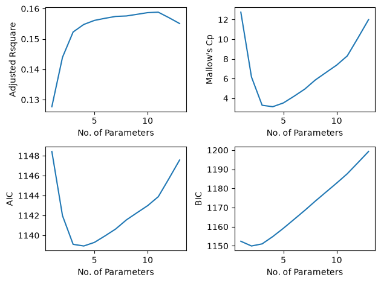

```python
import matplotlib.pyplot as plt


fig, axes = plt.subplots(2, 2)


axes[0, 0].plot(msize, rs['adj_rsq'])
axes[0, 0].set_xlabel("No. of Parameters")
axes[0, 0].set_ylabel("Adjusted Rsquare")


axes[0, 1].plot(msize, rs['cp'])
axes[0, 1].set_xlabel("No. of Parameters")
axes[0, 1].set_ylabel("Mallow's Cp")

axes[1, 0].plot(msize, Aic)
axes[1, 0].set_xlabel("No. of Parameters")
axes[1, 0].set_ylabel("AIC")

# R: plot(msize, Bic, xlab="No. of Parameters", ylab = "BIC")
axes[1, 1].plot(msize, Bic)
axes[1, 1].set_xlabel("No. of Parameters")
axes[1, 1].set_ylabel("BIC")

plt.tight_layout() # cleans it up
plt.show()
```

```python
best_k_aic = Aic.idxmin()
best_k_bic = Bic.idxmin()

comparison_df = pd.DataFrame({
    f'AIC-Best ({best_k_aic} features)': rs.loc[best_k_aic],
    f'BIC-Best ({best_k_bic} features)': rs.loc[best_k_bic]
})

comparison_df
```

|  | AIC-Best (3 features) | BIC-Best (1 features) |
| --- | --- | --- |
| k | 4 | 2 |
| predictors | (Medu, failures, freetime, goout) | (Medu, failures) |
| rsq | 0.16337 | 0.148313 |
| adj_rsq | 0.154789 | 0.143968 |
| bic | 2281.788229 | 2276.875838 |
| aic | 2261.8938 | 2264.93918 |
| rss | 6918.855608 | 7043.370273 |
| cp | 3.143431 | 6.164618 |

Note that the manually computed AIC and BIC values are different from those calculated using the sm package. But the difference is only a constant and so the same models are selected.

What are the 2nd and 3rd best models in terms of AIC/BIC? This cannot be answered by looking at the AIC/BIC plots shown above. Instead, we need to run the following code.

```python
all_models = []
for k in range(1, p + 1):
    for combo in itertools.combinations(X.columns, k):
        feature_set = list(combo)
        model = sm.OLS(y, sm.add_constant(X[feature_set])).fit()
        all_models.append({
            "num_features": len(feature_set),
            "features": feature_set,
            "rss": model.ssr
        })
all_models_df = pd.DataFrame(all_models)

# Get the top 3 models for each subset size, based on lowest RSS
nbest = 3
top_nbest_id = all_models_df.groupby('num_features')['rss'].nsmallest(nbest).index.get_level_values(1)
rs_1_df = all_models_df.loc[top_nbest_id]

# Replicate msize.1
msize_1 = rs_1_df['num_features']
```

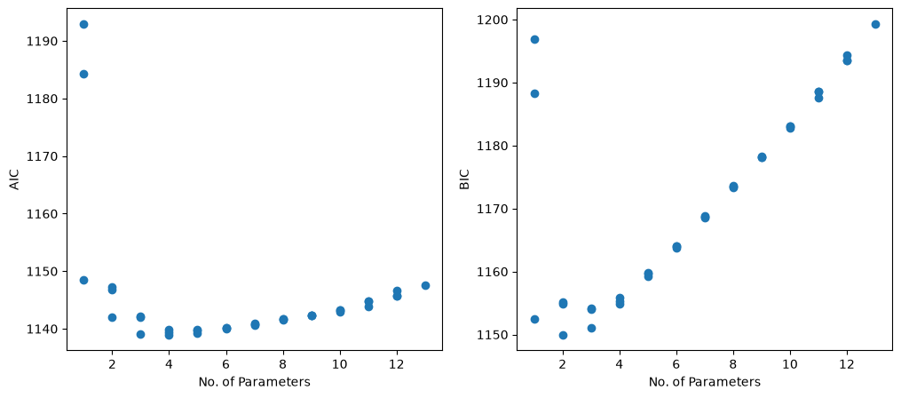

```python
fig, axes = plt.subplots(1, 2, figsize=(12, 5))

Aic_1 = n * np.log(rs_1_df['rss'] / n) + 2 * msize_1
Bic_1 = n * np.log(rs_1_df['rss'] / n) + msize_1 * np.log(n)

axes[0].scatter(msize_1, Aic_1)
axes[0].set_xlabel("No. of Parameters")
axes[0].set_ylabel("AIC")

axes[1].scatter(msize_1, Bic_1)
axes[1].set_xlabel("No. of Parameters")
axes[1].set_ylabel("BIC")
plt.show()
```

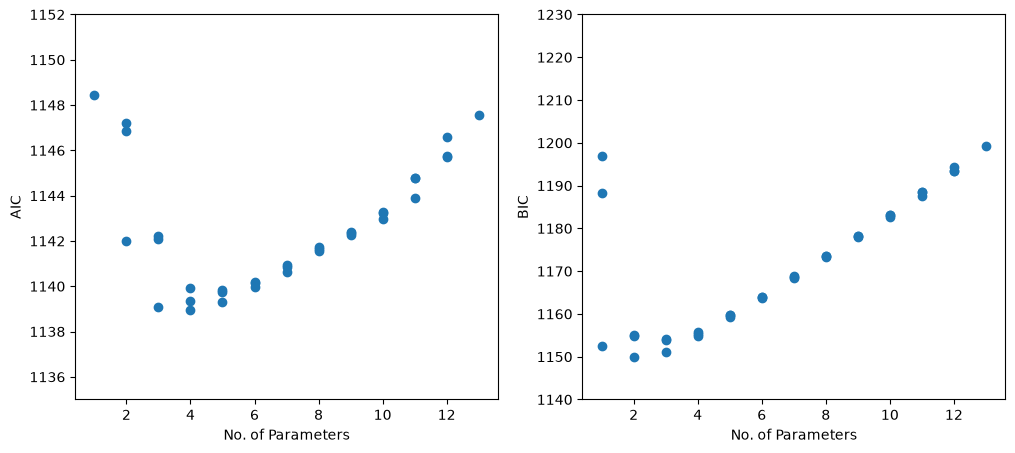

```python
fig, axes = plt.subplots(1, 2, figsize=(12, 5))

axes[0].scatter(msize_1, Aic_1)
axes[0].set_xlabel("No. of Parameters")
axes[0].set_ylabel("AIC")
axes[0].set_ylim(1135, 1152)

axes[1].scatter(msize_1, Bic_1)
axes[1].set_xlabel("No. of Parameters")
axes[1].set_ylabel("BIC")
axes[1].set_ylim(1140, 1230)
plt.show()
```

```python
which_df_1 = pd.DataFrame(False, index=rs_1_df.index, columns=X.columns)
for index, row in rs_1_df.iterrows():
    which_df_1.loc[index, row['features']] = True

# Add AIC/BIC to the df to sort
which_df_1['Aic'] = Aic_1
which_df_1['Bic'] = Bic_1

print("--- Top 3 models by AIC ---")
print(which_df_1.sort_values('Aic').head(3).drop(columns=['Aic', 'Bic']))

print("\n--- Top 3 models by BIC ---")
print(which_df_1.sort_values('Bic').head(3).drop(columns=['Aic', 'Bic']))
```

```
--- Top 3 models by AIC ---
        age  Medu   Fedu  traveltime  studytime  failures  famrel  freetime  \
712   False  True  False       False      False      True   False      True
186   False  True  False       False      False      True   False     False
1741  False  True  False        True      False      True   False      True

      goout   Dalc   Walc  health  absences
712    True  False  False   False     False
186    True  False  False   False     False
1741   True  False  False   False     False

--- Top 3 models by BIC ---
       age   Medu   Fedu  traveltime  studytime  failures  famrel  freetime  \
28   False   True  False       False      False      True   False     False
186  False   True  False       False      False      True   False     False
5    False  False  False       False      False      True   False     False

     goout   Dalc   Walc  health  absences
28   False  False  False   False     False
186   True  False  False   False     False
5    False  False  False   False     False
```

### Subset Selection via the `step` fucntion

We can use the **stepwise** approach to search possible models moving forward, backwards or in both directions (stepwise).

Python does not have a prebuilt function that mimicks the step function R. However, we can mimick this code using a for loop. Note that in the following function the default value for $k =2$, and uses AIC. The criteria can be changed to BIC by changing $k$ appropriately.

```python
import numpy as np
import statsmodels.formula.api as smf

def stepwise_selection(model, k=2): # For BIC, use k=np.log(len(model.model.data.frame))
    """
    Performs bidirectional (forward/backward) variable selection based on a criterion.
    Takes a fitted statsmodels model as input, mimicking R's step().
    """
    df = model.model.data.frame
    response = model.model.endog_names

    # Get initial predictors from the model, excluding the intercept
    initial_predictors = {p for p in model.model.exog_names if p != 'Intercept'}

    # Get all possible predictors from the dataframe
    all_predictors = {col for col in df.columns if col != response}

    included = initial_predictors
    excluded = all_predictors - included

    while True:
        # Define the current best model and its criterion
        current_formula = f"{response} ~ {' + '.join(included) or '1'}"
        current_model = smf.ols(current_formula, data=df).fit()
        # The fix is here: using .df_model instead of .df_modelwc
        current_criterion = -2 * current_model.llf + k * current_model.df_model

        best_candidate_criterion = current_criterion
        best_move = None

        # Check backward moves (dropping a variable)
        for var in included:
            formula = f"{response} ~ {' + '.join(included - {var}) or '1'}"
            temp_model = smf.ols(formula, data=df).fit()
            criterion = -2 * temp_model.llf + k * temp_model.df_model
            if criterion < best_candidate_criterion:
                best_candidate_criterion = criterion
                best_move = ('drop', var)

        # Check forward moves (adding a variable)
        for var in excluded:
            formula = f"{response} ~ {' + '.join(included | {var}) or '1'}"
            temp_model = smf.ols(formula, data=df).fit()
            criterion = -2 * temp_model.llf + k * temp_model.df_model
            if criterion < best_candidate_criterion:
                best_candidate_criterion = criterion
                best_move = ('add', var)

        # If a better model was found, make the move
        if best_move:
            move_type, var = best_move
            if move_type == 'drop':
                included.remove(var)
                excluded.add(var)
            else: # 'add'
                excluded.remove(var)
                included.add(var)
        else:
            # If no move improves the criterion, stop
            break

    final_formula = f"{response} ~ {' + '.join(included) or '1'}"
    return smf.ols(final_formula, data=df).fit()
```

```python
stepAIC = stepwise_selection(performance_full, k=2)
```

```python
n = len(stu_performance)
stepBIC = stepwise_selection(performance_full, k=np.log(n))
```

```python
stepAIC.summary()
```

OLS Regression Results

| Dep. Variable: | Grades | R-squared: | 0.163 |
| --- | --- | --- | --- |
| Model: | OLS | Adj. R-squared: | 0.155 |
| Method: | Least Squares | F-statistic: | 19.04 |
| Date: | Fri, 21 Aug 2026 | Prob (F-statistic): | 2.57e-14 |
| Time: | 12:15:59 | Log-Likelihood: | -1125.9 |
| No. Observations: | 395 | AIC: | 2262. |
| Df Residuals: | 390 | BIC: | 2282. |
| Df Model: | 4 |  |  |
| Covariance Type: | nonrobust |  |  |

|  | coef | std err | t | P>\|t\| | [0.025 | 0.975] |
| --- | --- | --- | --- | --- | --- | --- |
| Intercept | 9.8868 | 0.970 | 10.194 | 0.000 | 7.980 | 11.794 |
| goout | -0.5064 | 0.201 | -2.524 | 0.012 | -0.901 | -0.112 |
| freetime | 0.3254 | 0.222 | 1.465 | 0.144 | -0.111 | 0.762 |
| Medu | 0.6190 | 0.201 | 3.087 | 0.002 | 0.225 | 1.013 |
| failures | -1.9505 | 0.297 | -6.558 | 0.000 | -2.535 | -1.366 |

| Omnibus: | 37.170 | Durbin-Watson: | 2.041 |
| --- | --- | --- | --- |
| Prob(Omnibus): | 0.000 | Jarque-Bera (JB): | 45.218 |
| Skew: | -0.769 | Prob(JB): | 1.52e-10 |
| Kurtosis: | 3.618 | Cond. No. | 25.6 |

Notes:  
[1] Standard Errors assume that the covariance matrix of the errors is correctly specified.

```python
stepBIC.summary()
```

OLS Regression Results

| Dep. Variable: | Grades | R-squared: | 0.148 |
| --- | --- | --- | --- |
| Model: | OLS | Adj. R-squared: | 0.144 |
| Method: | Least Squares | F-statistic: | 34.13 |
| Date: | Fri, 21 Aug 2026 | Prob (F-statistic): | 2.16e-14 |
| Time: | 12:15:59 | Log-Likelihood: | -1129.5 |
| No. Observations: | 395 | AIC: | 2265. |
| Df Residuals: | 392 | BIC: | 2277. |
| Df Model: | 2 |  |  |
| Covariance Type: | nonrobust |  |  |

|  | coef | std err | t | P>\|t\| | [0.025 | 0.975] |
| --- | --- | --- | --- | --- | --- | --- |
| Intercept | 9.4821 | 0.621 | 15.267 | 0.000 | 8.261 | 10.703 |
| Medu | 0.5845 | 0.201 | 2.911 | 0.004 | 0.190 | 0.979 |
| failures | -2.0168 | 0.296 | -6.824 | 0.000 | -2.598 | -1.436 |

| Omnibus: | 35.775 | Durbin-Watson: | 2.001 |
| --- | --- | --- | --- |
| Prob(Omnibus): | 0.000 | Jarque-Bera (JB): | 42.955 |
| Skew: | -0.760 | Prob(JB): | 4.70e-10 |
| Kurtosis: | 3.545 | Cond. No. | 9.63 |

Notes:  
[1] Standard Errors assume that the covariance matrix of the errors is correctly specified.

Notice that all of the variables in stepBIC are strictly included in the variables of stepAIC

```python
stepAIC.model.exog_names
```

```
['Intercept', 'goout', 'freetime', 'Medu', 'failures']
```

```python
stepBIC.model.exog_names
```

```
['Intercept', 'Medu', 'failures']
```

```python
set(stepBIC.model.exog_names).issubset(set(stepAIC.model.exog_names))
```

```
True
```

### LASSO and RIDGE Regression

`SciKitLearn` has packages for Lasso and Ridge

```python
from sklearn.linear_model import LassoCV, RidgeCV
from sklearn.preprocessing import StandardScaler
from sklearn.model_selection import train_test_split
from sklearn.metrics import mean_squared_error
```

```python
X = stu_performance.drop(columns="Grades")
y = stu_performance["Grades"]
```

We'll first break up the data into train (80%) and test (20%) and create a full model.

```python
#split the data and assign
train_df, test_df = train_test_split(stu_performance, test_size=0.2, random_state=542) # seed for repoducibility
X_train = train_df.drop(columns="Grades")
Y_train = train_df["Grades"]
X_test = test_df.drop(columns="Grades")
Y_test = test_df["Grades"]
# first build the formula
predictors = stu_performance.columns.drop("Grades")
formula = "Grades ~ " + " + ".join(predictors)
# fitting and predicting
full_model = smf.ols(formula=formula, data=train_df).fit()
Y_pred = full_model.predict(X_test)

test_mse = mean_squared_error(Y_test, Y_pred)
print(test_mse)
```

```
19.596503898487
```

```python
full_model.summary()
```

OLS Regression Results

| Dep. Variable: | Grades | R-squared: | 0.197 |
| --- | --- | --- | --- |
| Model: | OLS | Adj. R-squared: | 0.163 |
| Method: | Least Squares | F-statistic: | 5.708 |
| Date: | Fri, 21 Aug 2026 | Prob (F-statistic): | 2.27e-09 |
| Time: | 12:15:59 | Log-Likelihood: | -892.81 |
| No. Observations: | 316 | AIC: | 1814. |
| Df Residuals: | 302 | BIC: | 1866. |
| Df Model: | 13 |  |  |
| Covariance Type: | nonrobust |  |  |

|  | coef | std err | t | P>\|t\| | [0.025 | 0.975] |
| --- | --- | --- | --- | --- | --- | --- |
| Intercept | 14.9099 | 3.759 | 3.966 | 0.000 | 7.513 | 22.307 |
| age | -0.2938 | 0.200 | -1.466 | 0.144 | -0.688 | 0.101 |
| Medu | 0.6554 | 0.287 | 2.286 | 0.023 | 0.091 | 1.219 |
| Fedu | -0.1495 | 0.277 | -0.539 | 0.590 | -0.695 | 0.396 |
| traveltime | -0.2962 | 0.338 | -0.876 | 0.382 | -0.962 | 0.369 |
| studytime | 0.2276 | 0.300 | 0.758 | 0.449 | -0.363 | 0.818 |
| failures | -1.9248 | 0.338 | -5.701 | 0.000 | -2.589 | -1.260 |
| famrel | 0.1149 | 0.265 | 0.433 | 0.665 | -0.407 | 0.637 |
| freetime | 0.4377 | 0.258 | 1.699 | 0.090 | -0.069 | 0.945 |
| goout | -0.6981 | 0.255 | -2.733 | 0.007 | -1.201 | -0.196 |
| Dalc | -0.1399 | 0.359 | -0.389 | 0.697 | -0.847 | 0.567 |
| Walc | 0.5134 | 0.266 | 1.927 | 0.055 | -0.011 | 1.038 |
| health | -0.2987 | 0.170 | -1.752 | 0.081 | -0.634 | 0.037 |
| absences | 0.0240 | 0.029 | 0.827 | 0.409 | -0.033 | 0.081 |

| Omnibus: | 25.184 | Durbin-Watson: | 2.164 |
| --- | --- | --- | --- |
| Prob(Omnibus): | 0.000 | Jarque-Bera (JB): | 28.864 |
| Skew: | -0.696 | Prob(JB): | 5.40e-07 |
| Kurtosis: | 3.503 | Cond. No. | 320. |

Notes:  
[1] Standard Errors assume that the covariance matrix of the errors is correctly specified.

Before proceeding, to better match glmnet in R which perform standardization, we scale our matrices.

```python
from sklearn.preprocessing import StandardScaler

# Fit scaler on training data
scaler_X = StandardScaler()
X_train_scaled = scaler_X.fit_transform(X_train)

# Apply same scaler to test data
X_test_scaled = scaler_X.transform(X_test)

# Center Y
Y_mean = Y_train.mean()
Y_train_centered = Y_train - Y_mean
Y_test_centered = Y_test - Y_mean  # for computing residuals/predictions
```

### Ridge Regression

```python
import numpy as np
from sklearn.linear_model import Ridge

alphas = np.logspace(-3, 3, 100)

coefs = []
intercepts = []

for a in alphas:
    ridge = Ridge(alpha=a, fit_intercept=False)  # intercept false to do it internally
    ridge.fit(X_train, Y_train)

    beta = ridge.coef_
    coefs.append(beta)

    # compute intercept "a0" like glmnet
    mean_X = X_train.mean(axis=0)
    mean_Y = Y_train.mean()
    a0 = mean_Y - np.dot(mean_X, beta)
    intercepts.append(a0)

beta_mat = np.column_stack(coefs)
a0_vec = np.array(intercepts)

ridge_lm = {
    "lambda": np.array(alphas),
    "beta": beta_mat,
    "a0": a0_vec
}
```

```python
len(ridge_lm["lambda"])

ridge_lm["beta"]

len(ridge_lm["a0"])

coef_mat = np.vstack([ridge_lm["a0"], ridge_lm["beta"]])
coef_mat.shape

# Check equivalence (should be ~0)
diff_sum = np.sum((coef_mat - np.vstack([ridge_lm["a0"], ridge_lm["beta"]]))**2)
print(diff_sum)
```

```
0.0
```

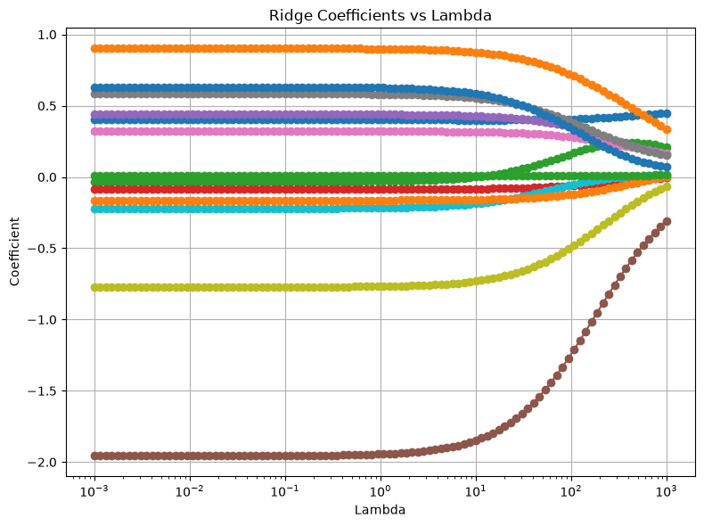

```python
lambdas = ridge_lm["lambda"]

# y-axis: coefficients
betas = ridge_lm["beta"]  # shape: (n_features, n_alphas)

plt.figure(figsize=(8,6))

# Plot each feature's coefficient across lambdas
for i in range(betas.shape[0]):
    plt.plot(lambdas, betas[i, :], marker='o')

plt.xscale('log')
plt.xlabel('Lambda')
plt.ylabel('Coefficient')
plt.title('Ridge Coefficients vs Lambda')
plt.grid(True)
plt.tight_layout()
plt.show()
```

```python
print(betas)
```

```
[[ 0.40065424  0.40065423  0.40065422 ...  0.44213502  0.44483945
   0.4473361 ]
 [ 0.90278352  0.90278309  0.90278259 ...  0.38252752  0.35854272
   0.33530576]
 [-0.0334491  -0.03344854 -0.03344789 ...  0.2253532   0.21806843
   0.20998266]
 ...
 [ 0.63150802  0.63150725  0.63150635 ...  0.0860461   0.07879499
   0.07282743]
 [-0.16322124 -0.16322116 -0.16322108 ... -0.01152455 -0.00295593
   0.00536963]
 [ 0.00889445  0.00889445  0.00889445 ...  0.01289868  0.01370775
   0.01462151]]
```

Computing intercepts

```python
k = 1  # since python is 0-indexed

# manual intercept
mean_ridge = X_train.mean(axis=0)
intercept_manual = Y_train.mean() - np.sum(mean_ridge * beta_mat[:, k])

# stored intercept
intercept_model = a0_vec[k]

# both approaches give the same
diff_sq_sum = np.sum(
    (Y_train.mean() - mean_ridge @ beta_mat - a0_vec)**2
)

print(diff_sq_sum)
```

```
1.735493991486226e-28
```

By computing the Residual sum of squares for the null model and at various lambda values, we can plot the fitted coefficients against the percent deviance. This is the percent of deviance explained on the training data, and is a measure of complexity of the model. We can see that the coefficients do not change much after a point the but the coefficients start blowing up a bit.

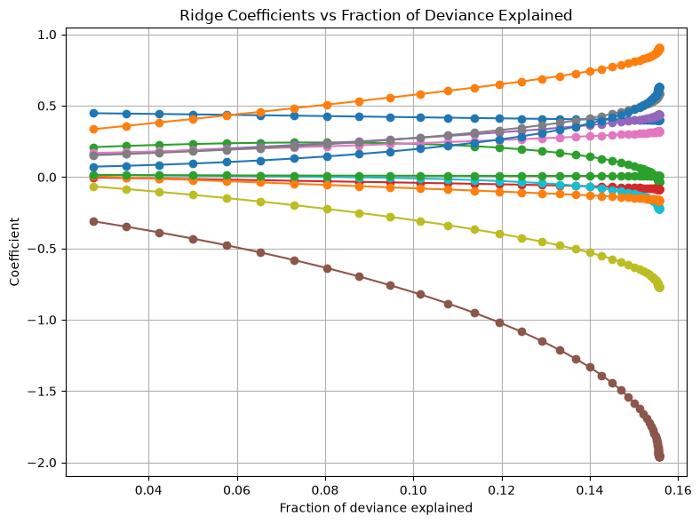

```python
mean_Y = Y_train.mean()
RSS0 = np.sum((Y_train - mean_Y)**2)

RSS_lambda = []
for k in range(beta_mat.shape[1]):
    y_pred = X_train @ beta_mat[:, k] + a0_vec[k]
    rss = np.sum((Y_train - y_pred)**2)
    RSS_lambda.append(rss)

RSS_lambda = np.array(RSS_lambda)

# Fraction of deviance explained
dev_explained = 1 - RSS_lambda / RSS0

# Plot coefficients vs fraction of deviance explained
plt.figure(figsize=(8,6))
for i in range(beta_mat.shape[0]):
    plt.plot(dev_explained, beta_mat[i, :], marker='o', label=f'Feature {i+1}')

plt.xlabel('Fraction of deviance explained')
plt.ylabel('Coefficient')
plt.title('Ridge Coefficients vs Fraction of Deviance Explained')
plt.grid(True)
plt.tight_layout()
plt.show()
```

#### Comparing Python & R Results for Ridge

In this section we will highlight that Ridge in `sklearn` uses a different loss function from the elastic net used by `glmnet`. Some code will be shown for this conversion.

- This is only for those comparing against peers with R code and you mostly will not need to be worried about this.

```python
from sklearn.model_selection import cross_val_score
N = X_train_scaled.shape[0]
alphas = np.exp(np.linspace(-2,4,100))*(N/2)
cv_scores = []
cv_stds = []
for alpha in alphas:
    ridge = Ridge(alpha=alpha)
    scores = cross_val_score(ridge, X_train_scaled, Y_train_centered, cv=10, scoring='neg_mean_squared_error')
    cv_scores.append(-scores.mean())        # mean CV MSE
    cv_stds.append(scores.std()/np.sqrt(10))  # SE across folds


cv_mse = np.array(cv_scores)
cv_std = np.array(cv_stds)

alpha_min = alphas[np.argmin(cv_mse)]
alpha_1se = alphas[np.where(cv_mse <= cv_mse.min() + cv_std[np.argmin(cv_mse)])[0][-1]] # largest lambda whose mse is within one std of min MSE

print(alpha_min)
print(alpha_1se)

print(alpha_min*(2/N)) #equivalent in glmnet (https://stats.stackexchange.com/questions/160096/what-are-the-differences-between-ridge-regression-using-rs-glmnet-and-pythons)
print(alpha_1se*(2/N))
```

```
76.34956282799241
1895.8897224818531
0.4832250811898254
11.999302041024388
```

```python
alphas
```

```
array([  21.38297475,   22.71898898,   24.13847775,   25.64665657,
         27.24906682,   28.95159612,   30.76049992,   32.68242453,
         34.72443153,   36.8940237 ,   39.19917259,   41.64834782,
         44.25054821,   47.0153348 ,   49.95286603,   53.07393504,
         56.3900093 ,   59.91327281,   63.6566708 ,   67.63395735,
         71.85974586,   76.34956283,   81.11990481,   86.18829908,
         91.57336805,   97.29489762,  103.37390996,  109.83274069,
        116.69512096,  123.98626466,  131.73296106,  139.9636732 ,
        148.70864254,  158.        ,  167.87188407,  178.3605662 ,
        189.50458412,  201.34488339,  213.92496786,  227.29105951,
        241.4922683 ,  256.58077258,  272.61201081,  289.64488527,
        307.74197849,  326.96978313,  347.39894637,  369.10452943,
        392.16628337,  416.66894213,  442.70253384,  470.36271162,
        499.75110503,  530.97569345,  564.15120286,  599.39952736,
        636.850177  ,  676.64075367,  718.91745668,  763.83561987,
        811.56028244,  862.26679522,  916.14146507,  973.38223932,
       1034.19943311, 1098.81650212, 1167.47086363, 1240.41476879,
       1317.9162295 , 1400.26000308, 1487.7486386 , 1580.70358847,
       1679.46638953, 1784.39991794, 1895.88972248, 2014.3454411 ,
       2140.20230606, 2273.92274303, 2415.99807021, 2566.95030345,
       2727.33407432, 2897.73866793, 3078.79018808, 3271.15385769,
       3475.53646304, 3692.68895056, 3923.40918607, 4168.54488625,
       4428.99673334, 4705.72168447, 4999.73648773, 5312.12141789,
       5644.02424561, 5996.66445458, 6371.33772216, 6769.42067998,
       7192.37597204, 7641.7576287 , 8119.21677661, 8626.50770524])
```

```python
cv_mse
```

```
array([18.22137631, 18.21558808, 18.20973165, 18.20382677, 18.19789572,
       18.19196342, 18.18605756, 18.1802087 , 18.17445034, 18.16881905,
       18.16335448, 18.15809941, 18.15309976, 18.14840457, 18.14406595,
       18.140139  , 18.13668168, 18.13375464, 18.13142108, 18.12974641,
       18.12879806, 18.1286451 , 18.12935788, 18.1310076 , 18.13366588,
       18.13740428, 18.14229372, 18.14840397, 18.15580305, 18.16455664,
       18.17472747, 18.18637472, 18.19955338, 18.21431368, 18.23070054,
       18.24875298, 18.26850364, 18.28997833, 18.31319558, 18.33816634,
       18.36489361, 18.3933723 , 18.42358898, 18.45552184, 18.48914063,
       18.52440675, 18.56127329, 18.59968532, 18.63958002, 18.6808871 ,
       18.72352914, 18.76742205, 18.81247557, 18.85859382, 18.90567594,
       18.95361676, 19.00230747, 19.05163637, 19.10148966, 19.15175219,
       19.20230827, 19.25304249, 19.30384044, 19.35458955, 19.40517978,
       19.45550433, 19.50546031, 19.55494931, 19.60387791, 19.65215823,
       19.69970821, 19.74645204, 19.7923203 , 19.83725021, 19.88118567,
       19.92407729, 19.96588239, 20.00656483, 20.04609488, 20.08444903,
       20.12160969, 20.15756493, 20.19230816, 20.22583777, 20.25815679,
       20.2892725 , 20.3191961 , 20.34794227, 20.37552886, 20.40197651,
       20.42730827, 20.45154933, 20.47472662, 20.4968686 , 20.5180049 ,
       20.5381661 , 20.55738347, 20.57568878, 20.59311406, 20.60969143])
```

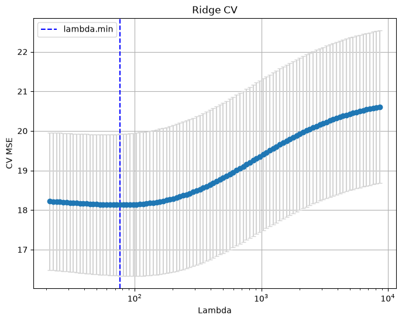

```python
plt.figure(figsize=(8,6))
plt.errorbar(alphas, cv_mse, yerr=cv_std, fmt='-o', ecolor='lightgray', capsize=3)
plt.xscale('log')
plt.xlabel('Lambda')
plt.ylabel('CV MSE')
plt.title('Ridge CV')
plt.axvline(alpha_min, color='blue', linestyle='--', label='lambda.min')
plt.legend()
plt.grid(True)
plt.show()
```

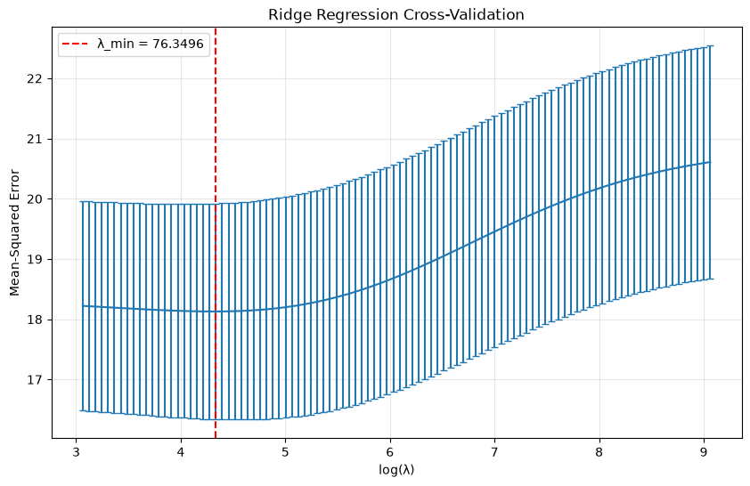

```python
cv_mse = np.array(cv_scores)
cv_std = np.array(cv_stds)

#change name to make compatible with R

lambda_seq = alphas
lambda_min_idx = np.argmin(cv_mse)
lambda_min = lambda_seq[lambda_min_idx]

lambda_min_idx = np.argmin(cv_mse)
lambda_min = lambda_seq[lambda_min_idx] # get lambda of minimum mse

plt.figure(figsize=(10, 6))
plt.errorbar(np.log(lambda_seq), cv_mse, yerr=cv_std, capsize=3)
plt.xlabel('log(λ)')
plt.ylabel('Mean-Squared Error')
plt.title('Ridge Regression Cross-Validation')
plt.axvline(np.log(lambda_min), color='red', linestyle='--', label=f'λ_min = {lambda_min:.4f}')
plt.legend()
plt.grid(True, alpha=0.3)
plt.show()
```

#### Prediction

Now we use these minimum values to perform prediction on the test data.

```python
# Fit Ridge for all alphas
ridge_preds = {}
for alpha in alphas:
    ridge = Ridge(alpha=alpha, fit_intercept=False)
    ridge.fit(X_train_scaled, Y_train_centered)
    ridge_preds[alpha] = ridge

# Using alpha_min
ridge_min = ridge_preds[alpha_min]
Ytest_ridge_min_pred = ridge_min.predict(X_test_scaled) + Y_train.mean()  # add back mean if Y was centered
mse_min = np.mean((Ytest_ridge_min_pred - Y_test) ** 2)
print("MSE (alpha_min):", mse_min)

# Using alpha_1se
ridge_1se = ridge_preds[alpha_1se]
Ytest_ridge_1se_pred = ridge_1se.predict(X_test_scaled) + Y_train.mean()
mse_1se = np.mean((Ytest_ridge_1se_pred - Y_test) ** 2)
print("MSE (alpha_1se):", mse_1se)
```

```
MSE (alpha_min): 19.042536531458424
MSE (alpha_1se): 20.432799172444795
```

#### LASSO Regression

For Lasso we will use Lasso and LassoCV

```python
from sklearn.linear_model import Lasso
```

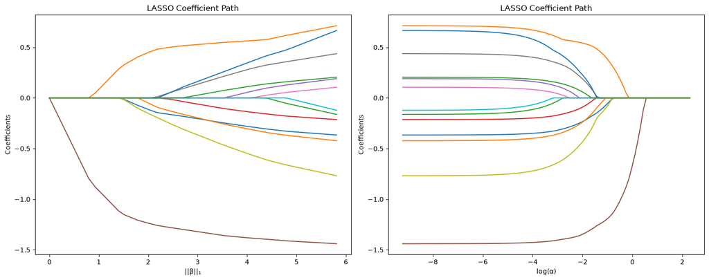

```python
n_samples = X_train_scaled.shape[0]
alphas = np.logspace(-4, 1, 100)
lasso_lm = Lasso()

# Plot coefficient paths (equivalent to plot(lasso.lm))
fig, (ax1, ax2) = plt.subplots(1, 2, figsize=(15, 6))

# Plot 1: Coefficients vs L1 norm
l1_norms = []
coeffs_path = []
for alpha in alphas:
    lasso_temp = Lasso(alpha=alpha, max_iter=10000)
    lasso_temp.fit(X_train_scaled, Y_train_centered)
    coeffs_path.append(lasso_temp.coef_)
    l1_norms.append(np.sum(np.abs(lasso_temp.coef_)))

coeffs_path = np.array(coeffs_path)
for i in range(coeffs_path.shape[1]):
    ax1.plot(l1_norms, coeffs_path[:, i])
ax1.set_xlabel('||β||₁')
ax1.set_ylabel('Coefficients')
ax1.set_title('LASSO Coefficient Path')


for i in range(coeffs_path.shape[1]):
    ax2.plot(np.log(alphas), coeffs_path[:, i])
ax2.set_xlabel('log(α)')
ax2.set_ylabel('Coefficients')
ax2.set_title('LASSO Coefficient Path')
plt.tight_layout()
plt.show()
```

```python
# Extract degrees of freedom (number of non-zero coefficients)
df = [np.sum(coef != 0) for coef in coeffs_path]
print("Degrees of freedom:", df)
```

```
Degrees of freedom: [np.int64(13), np.int64(13), np.int64(13), np.int64(13), np.int64(13), np.int64(13), np.int64(13), np.int64(13), np.int64(13), np.int64(13), np.int64(13), np.int64(13), np.int64(13), np.int64(13), np.int64(13), np.int64(13), np.int64(13), np.int64(13), np.int64(13), np.int64(13),…
```

```python
# cross validation using LassoCV
lasso_cv = LassoCV(alphas=alphas, cv=10, max_iter=10000)
lasso_cv.fit(X_train_scaled, Y_train_centered)

# Cross-validation scores for plotting
cv_scores = []
cv_stds = []
for alpha in alphas:
    lasso = Lasso(alpha=alpha, max_iter=10000)
    scores = cross_val_score(lasso, X_train_scaled, Y_train_centered, cv=10, scoring='neg_mean_squared_error')
    cv_scores.append(-scores.mean())
    cv_stds.append(scores.std() / np.sqrt(len(scores)))

cv_mse = np.array(cv_scores)
cv_std = np.array(cv_stds)
```

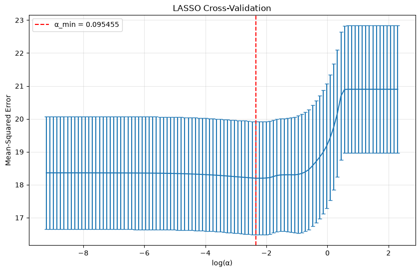

```
alpha.min: 0.09545484566618337
alpha.1se: 1.232846739442066
```

```python
# plot(lasso.cv)
plt.figure(figsize=(10, 6))
plt.errorbar(np.log(alphas), cv_mse, yerr=cv_std, capsize=3)
plt.xlabel('log(α)')
plt.ylabel('Mean-Squared Error')
plt.title('LASSO Cross-Validation')
plt.axvline(np.log(lasso_cv.alpha_), color='red', linestyle='--', label=f'α_min = {lasso_cv.alpha_:.6f}')
plt.legend()
plt.grid(True, alpha=0.3)
plt.show()

# lambda.min and lambda.1se
alpha_min = lasso_cv.alpha_
alpha_min_idx = np.argmin(cv_mse)
alpha_1se_idx = np.where(cv_mse <= cv_mse[alpha_min_idx] + cv_std[alpha_min_idx])[0][-1]
alpha_1se = alphas[alpha_1se_idx]

print(f"alpha.min: {alpha_min}")
print(f"alpha.1se: {alpha_1se}")
```

```python
# Extract coefficients
lasso_min = Lasso(alpha=alpha_min, max_iter=10000)
lasso_min.fit(X_train_scaled, Y_train_centered)
lasso_min_coef = lasso_min.coef_

lasso_1se = Lasso(alpha=alpha_1se, max_iter=10000)
lasso_1se.fit(X_train_scaled, Y_train_centered)
lasso_1se_coef = lasso_1se.coef_

# Display coefficients side by side
coef_comparison = np.column_stack([lasso_min_coef, lasso_1se_coef])
print("Coefficients (min, 1se):")
print(coef_comparison)

# Number of variables selected
print(f"Number of non-zero coefficients (1se): {np.sum(lasso_1se_coef != 0)}")
print(f"Number of non-zero coefficients (min): {np.sum(lasso_min_coef != 0)}")
```

```
Coefficients (min, 1se):
[[-0.27135531 -0.        ]
 [ 0.55895989  0.        ]
 [-0.          0.        ]
 [-0.12746314 -0.        ]
 [ 0.0394935   0.        ]
 [-1.37489405 -0.43215856]
 [ 0.          0.        ]
 [ 0.26149608  0.        ]
 [-0.52568281 -0.        ]
 [-0.         -0.        ]
 [ 0.32234414 -0.        ]
 [-0.29201279 -0.        ]
 [ 0.10107942  0.        ]]
Number of non-zero coefficients (1se): 1
Number of non-zero coefficients (min): 10
```

```python
# Names of selected variables (assuming you have feature names)
selected_features_1se = np.where(lasso_1se_coef != 0)[0]
selected_features_min = np.where(lasso_min_coef != 0)[0]
print(f"Selected features (1se): {selected_features_1se}")
print(f"Selected features (min): {selected_features_min}")
```

```
Selected features (1se): [5]
Selected features (min): [ 0  1  3  4  5  7  8 10 11 12]
```

```python
stu_performance.columns[selected_features_1se].tolist()
```

```
['failures']
```

```python
stu_performance.columns[selected_features_min].tolist()
```

```
['age',
 'Medu',
 'traveltime',
 'studytime',
 'failures',
 'freetime',
 'goout',
 'Walc',
 'health',
 'absences']
```

#### Predictions on test data

```python
Y_test_lasso_min_pred = lasso_min.predict(X_test_scaled)
mse_min = np.mean((Y_test_lasso_min_pred - Y_test_centered)**2)
print(f"Test MSE (alpha.min): {mse_min}")

Y_test_lasso_1se_pred = lasso_1se.predict(X_test_scaled)
mse_1se = np.mean((Y_test_lasso_1se_pred - Y_test_centered)**2)
print(f"Test MSE (alpha.1se): {mse_1se}")
```

```
Test MSE (alpha.min): 19.2654246696838
Test MSE (alpha.1se): 20.58268401793688
```

### Refit to Reduce Bias

We refit an ordinary linear regression model using the variables selected by `lambda.1se` and then use it for prediction.

```python
from sklearn.linear_model import LinearRegression

# Get selected variables from 1se model
selected_indices_1se = np.where(lasso_1se_coef != 0)[0]

# Create subset of scaled data with only selected variables
tmp_X_train = X_train_scaled[:, selected_indices_1se]
tmp_X_test = X_test_scaled[:, selected_indices_1se]

# Refit linear regression on selected variables
lasso_refit = LinearRegression()
lasso_refit.fit(tmp_X_train, Y_train_centered)

# Predict on test data
Y_test_pred = lasso_refit.predict(tmp_X_test)
mse_refit = np.mean((Y_test_pred - Y_test_centered)**2)
print(f"Refitted model MSE: {mse_refit}")
```

```
Refitted model MSE: 19.227935377709333
```